# Pedon Data with R Cheatsheet

v0.1.0 - last updated 2019/01/31

Andrew Brown; andrew.g.brown@ca.usda.gov

# 1 Pedon Data with R Cheatsheet

This “cheatsheet” provides explanation of some of the most common workflows and techniques you will need when using the *aqp* **SoilProfileCollection** object to hold soil profile (pedon) data.

To get this document as an .R file click here.

## 1.1 NCSS-Tech (Soil-related) Packages

With `install.packages()` you can get the “stable” versions of *aqp*, *soilDB* and *sharpshootR* off of the official R package repository (CRAN) .

```r
install.packages(c("aqp","soilDB","sharpshootR"))
```

You can get the latest “development” versions of ncss-tech packages from GitHub.

```r
# install.packages("remotes") # if needed
remotes::install_github(repo = 'ncss-tech/aqp', dependencies = FALSE, build = FALSE)
remotes::install_github(repo = 'ncss-tech/soilDB', dependencies = FALSE, build = FALSE)
remotes::install_github(repo = 'ncss-tech/sharpshootR', dependencies = FALSE, build = FALSE)
```

Note that *soilReports* package (containing, for instance, the map unit comparison report) is ONLY available **FROM GitHub**.

```r
remotes::install_github(repo = 'ncss-tech/soilReports', dependencies = FALSE, build = FALSE)
```

After installing, load the packages with `library()` to use them in your R environment.

```r
library(aqp)
library(soilDB)
library(sharpshootR)
library(soilReports)
```

# 2 SoilProfileCollection

## 2.1 SPC from soilDB sample dataset

Load one of the sample (NASIS) datasets from *soilDB* package

```r
data("loafercreek")
```

## 2.2 SPCs from NASIS

Get data from NASIS (requires [ODBC connection](http://ncss-tech.github.io/AQP/soilDB/setup_local_nasis.html) to local NASIS db). You can create SPCs from [pedon (point data)](http://ncss-tech.github.io/AQP/soilDB/fetchNASIS-mini-tutorial.html) or [aggregated data (map unit components)](http://ncss-tech.github.io/AQP/soilDB/NASIS-component-data.html).

```r
fetchNASIS() # default argument of fetchNASIS() gets pedons
fetchNASIS_pedons()
fetchNASIS_components()
```

## 2.3 SPCs from Kellogg Soil Survey Lab database

KSSL Data by taxon name

```r
fetchKSSL(series = "Holland")
```

KSSL Data by MLRA (overlap of site coordinates with MLRA shapefile)

```r
fetchKSSL(mlra = "15")
```

KSSL Data by rectangular bounding box (specified in longitude and latitude)

```r
fetchKSSL(bbox = c(-119, 37, -120, 38))
```

Additional [`fetchKSSL` examples](http://ncss-tech.github.io/AQP/soilDB/KSSL-demo.html).

## 2.4 SPCs from SSURGO/STATSGO (SDA) components

Fetch component and component horizon information from Soil Data Access (interface to SSURGO/STATSGO) subject to a user-specified WHERE constraint.

```r
fetchSDA_component(WHERE = "compname = 'Mantree'")
```

See the “SDA Query Help” page for information on database schema, table/column definitions, etc.

https://sdmdataaccess.nrcs.usda.gov/QueryHelp.aspx

You can also evaluate *arbitrary* SDA queries (where you do all the joins to tables of interest *yourself*).

```r
SDA_query(q = "SELECT * FROM legend AS l
                INNER JOIN mapunit mu ON l.lkey = mu.lkey
                INNER JOIN component co ON mu.mukey = co.mukey
               WHERE areasymbol = 'CA630' AND compname = 'Mantree';")
```

Additional [`SDA_query` examples](http://ncss-tech.github.io/AQP/soilDB/SDA-tutorial.html).

## 2.5 SPCs from Soil Classification database

Create an SPC containing OSDs from Soil Classification (SC) database (an input vector of series names is provided).

```r
your.spc <- fetchOSD(soils = c("Holland", "Musick"))
```

Summarize climatic/physiographic/component attribute breakdown and get morphologic data using argument `extended=TRUE`.

```r
your.extended.list <- fetchOSD(soils = "Holland", extended = TRUE)

#the SPC can be found in the SPC attribute when extended=TRUE
your.extended.list$SPC
```

# 3 Accessing SPCs

[Detailed `SoilProfileCollection` tutorial](http://ncss-tech.github.io/AQP/aqp/aqp-intro.html).

Get site *data.frame* from `loafercreek` SPC.

```r
site(loafercreek)
```

Determine the **number of profiles** in an SPC.

```r
# overload of generic "length" function
length(loafercreek)
# this also works because each profile in the collection must have site level attributes
nrow(site(loafercreek))
```

Get site *data.frame* from `loafercreek` SPC.

```r
site(loafercreek)
```

Get horizon *data.frame* from `loafercreek` SPC.

```r
horizons(loafercreek)
```

Determine the **number of horizons** in an SPC.

```r
# overload of generic "nrow" function
nrow(loafercreek)
nrow(horizons(loafercreek))
```

Create a subset SPC based on a site-level attribute using`subsetProfiles()` and argument `s` containing an expression to evaluate. Here we write an expression to select all profiles that have a field-measured slope gradient *less than 8 percent*.

```r
sub1 <- subsetProfiles(loafercreek, s='slope_field < 8')
```

Create a subset SPC based on a horizon-level attribute using`subsetProfiles()` and argument `h` containing an expression to evaluate. Here we write an expression select all profiles that have *one or more horizons* with clay content greater than 35 percent. Note that horizon data are not modified.

```r
sub2 <- subsetProfiles(loafercreek, h = 'clay > 35')
```

## 3.1 Create a subset SPC based on a list of user pedon IDs

First, make a character vector (using `c()`) to concatenate a set of character strings (the user pedon IDs that you want).

```r
your.list <- c("07SKC016", "10MJE016", "10CKS034", "S2000CA007012", "06SMM013" )
```

Create a `TRUE`/`FALSE` (logical) vector by checking each user pedon ID in `loafercreek` to see if it matches one in `your.list`.

```r
matches.your.list <- site(loafercreek)$pedon_id %in% your.list
```

Note that the length of the vector `matches.your.list` equals `nrow(site(loafercreek))`.

The number of `TRUE` values in `matches.your.list` (`sum(matches.your.list)`) is equal to `length(your.list)`. This is because all user pedon IDs in the list were found. If `sum(matches.your.list) < length(your.list)` some in the list were NOT found.

To get just the positions (index) where the logical vector `matches.your.list` is `TRUE` use `which()`

```r
your.matching.indices <- which(matches.your.list)
```

Create a new SPC `loafercreek.subset` that is the subset corresponding to your “matching” indices.

Use the *data.frame*-like square bracket notation `spc[site.index, horizon.index]` to access the sites corresponding to your matching user pedon IDs.

```r
loafercreek.subset <- loafercreek[your.matching.indices, ]
```

# 4 Editing SPCs

Create a site or horizon-level variable.

```r
# be sure to specify the correct length
loafercreek$foo <- 1:length(loafercreek)

# be sure to specify a vector that is the correct length
loafercreek$foohz <- 1:nrow(loafercreek)

# note that this one causes an error. Test your understanding: why?
horizons(loafercreek)$foohz2 <- 1:nrow(site(loafercreek))
```

Create a site or horizon-level variable *without having replacement equal to number of sites/horizons* by explicitly calling `site()` or `horizons()`. Here since the replacement is length `1` it is set for all sites/horizons. This is the only way to set a site or horizon attribute that is not equal to the length of the respective *data.frame*.

```r
# vectors shorter than length(SPC) are recycled
site(loafercreek)$foo <- 2

# vectors shorter than nrow(SPC) are recycled
horizons(loafercreek)$foo <- 2
```

Add multiple attributes to the site data of a SPC based on common (unique) site id (for example: `id`). An SPC is smart enough to to *LEFT JOIN* on a shared site column (must be present in new data data.frame `your.site.data`). Ideally, you would use a unique ID such as the one used to initialize the SPC. You can check what is currently used via `idname(SPC)` and `profile_id(SPC)`.

This type of site level assignment results in an SPC with the unique site level attributes resulting from the join. The original site level attributes are not modified when using `site()` in this manner.

```r
site(your.spc) <- your.site.data
```

Adding horizon data to the SPC based on common (unique) horizon id (for example: `hzid`) is a little more complicated. You need to be careful when using direct replacement (like below) to make sure that you do not accidentally remove horizon records. Force all records from the original data to be retained by setting `all.x = TRUE`. Care must also be taken to avoid duplication of horizon records.

```r
horizons(your.spc) <- merge(horizons(your.spc), your.horizon.data, by = "hzid", all.x=TRUE)
```

There are plans for implementing a left-join style interface to horizon level attributes.

# 5 Combining SPCs

Load *another* SPC to combine with `loafercreek`

```r
data("loafercreek")
data("gopheridge")
```

Make a `list()` of SPCs, and combine them with `union()`

```r
loafergopher <- union(list(loafercreek, gopheridge))
```

# 6 Plotting SPCs

Make a plot of first 10 profiles in `loafercreek`. `plot(your.spc)` is an alias (shorthand) for `plotSPC()`

```r
plot(loafercreek[1:10, ], label = "pedon_id")
```

Make a plot of first 10 profiles in `loafercreek`, this time grouped by *taxonname*. The default margins are a bit small, you will typically want to adjust these with `par()` depending on the number of profiles in the collection.

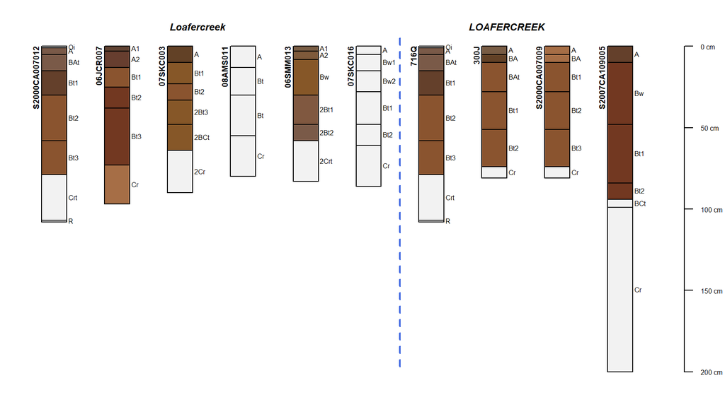

```r
# adjust margins, units are inches, bottom, left, top, right
par(mar=c(1,1,0.5,1))

groupedProfilePlot(loafercreek[1:10, ], groups = "taxonname",
                  label = "pedon_id", id.style="side",
                  axis.line.offset = -1.5, group.name.offset = -10)
```

To make this plot “nice” we set the default label position style to “side” and label with the the `pedon_id` (*NASIS user pedon ID*) instead of `peiid` (*NASIS pedon record id*).

We adjust the depth axis offset (units of “profile index” - the *x* dimension) to the right. This is done so the axis does not plot on top of the horizon designations of the farthest profile to the right.

Also, we set the vertical `group.name.offset` (specified using depth units, *centimeters* in this case) so the top of the profiles do not overlap the group labels containing the *taxonname*. Specifying a vector of offsets (e.g. `group.name.offset=c(-10, -15)`) is a convenient way to avoid overlap when collections and / or group names are large.

There are *many, many more* plotting options that can be found in the helpfiles. See `?plotSPC` and `?groupedProfilePlot`. More ideas in the [SPC tutorial](http://ncss-tech.github.io/AQP/aqp/aqp-intro.html) and in [this tutorial](http://ncss-tech.github.io/AQP/aqp/SPC-plotting-ideas.html).

# 7 Making Spatial SPCs

## 7.1 Set coordinates and reference system for NASIS-derived pedon

Set coordinates to be NASIS standard decimal degrees longitude `x_std` and latitude `y_std`. You provide the right hand side of a formula that describes how to promote the SPC to spatial with `coordinates()`.

```r
coordinates(loafercreek) <- ~ x_std + y_std
```

You need to set the [*initially blank*] coordinate reference system (CRS) to the NASIS standard (WGS84 decimal degrees). We use a string representation of the coordinate reference system called the “proj4string” to specify what want.

```r
proj4string(loafercreek) <- '+proj=longlat +datum=WGS84'
```

If you specify *longitude* first (`x_std`) in your formula to `coordinates()`, use `longlat` in your proj4string. Otherwise use `latlong`.

If your coordinates are in a different system (e.g. projected in UTM) you will need to specify e.g. UTM zone in the `proj4string()` you supply. Check out `?proj4string` for more info on how to use other CRSs.

## 7.2 Working with spatial data

Create a *SpatialPointsDataFrame* from SPC (contains just **SITE**-level data)

```r
loafercreek.spdf <- as(loafercreek, 'SpatialPointsDataFrame')
```

Plot site locations in *SpatialPointsDataFrame*

```r
plot(loafercreek.spdf)
```

Write *SpatialPointsDataFrame* derived from an SPC to a shapefile (*do not use ‘.shp’ extension in `layer` argument that specifies the file name*)

```r
rgdal::writeOGR(obj = loafercreek.spdf, layer = 'output.shapefile.name', driver = 'ESRI Shapefile')
```

This document is based on `aqp` version 1.17, `soilDB` version 2.3.6, and `sharpshootR` version 1.4.